# ANOVA

Maxwel Coura Oliveira  
2022-07-01

# Importando os pacotes

Vamos importar alguns pacotes até o final dessa aula, porém vamos trabalhar na base tidyverse. O tidyverse é um pacote que contém vários outros pacotes que auxiliam na manipulação de dados e construção de gráficos. Um exemplo que vamos usar é o pipe (%>%) do pacote magrittr (ou pode-se usar o |> da base R), que faz parte do tidyverse. Assim como o pacote `dplyr` (que está dentro do `tidyverse`) para manipulação de dados.

```r
library(tidyverse)
```

# Dados

Parte dos resultados de [Confirmation and control of HPPD-inhibiting herbicide–resistant waterhemp (Amaranthus tuberculatus) in Nebraska](https://maxweeds.rbind.io/pdf/2017-confirmation-wat.pdf) de Oliveira et al. (2017). Nove herbicidas pré-emergentes aplicados em milho. Os estudos foi conduzido em lavoura de milho em 2013 e 2014.

Vamos usar o pacote `RCurl` para baixar o pacote via GitHub.

```r
library(RCurl)
```

```r
# Baixando via GitHub
df_path <- url("https://raw.githubusercontent.com/maxwelco/workshop-esalq/main/data/residual.csv")

# Lendo via read_csv
residual <- read_csv(df_path)

residual
```

```
# A tibble: 54 × 7
   weed       year herbicide            trt   rep   dat control
   <chr>     <dbl> <chr>              <dbl> <dbl> <dbl>   <dbl>
 1 waterhemp  2014 SureStart              1     1    34     100
 2 waterhemp  2014 SureStart              1     2    34     100
 3 waterhemp  2014 SureStart              1     3    34      95
 4 waterhemp  2014 Lumaz EZ + Harness     2     1    34      50
 5 waterhemp  2014 Lumaz EZ + Harness     2     2    34      30
 6 waterhemp  2014 Lumaz EZ + Harness     2     3    34      70
 7 waterhemp  2014 Zidua_1                3     1    34      70
 8 waterhemp  2014 Zidua_1                3     2    34     100
 9 waterhemp  2014 Zidua_1                3     3    34      80
10 waterhemp  2014 Zidua_2                4     1    34      85
# … with 44 more rows
```

# Manipulação dos dados

O resultado (control), % de controle de planta daninha (`waterhemp`) está em uma escala de 0 a 100, precisamos colocar em uma escala entre 0 e 1 (proporção)

```r
residual1 <- residual %>%
  mutate(control_prop = control / 100)

residual1
```

```
# A tibble: 54 × 8
   weed       year herbicide      trt   rep   dat control control_prop
   <chr>     <dbl> <chr>        <dbl> <dbl> <dbl>   <dbl>        <dbl>
 1 waterhemp  2014 SureStart        1     1    34     100         1
 2 waterhemp  2014 SureStart        1     2    34     100         1
 3 waterhemp  2014 SureStart        1     3    34      95         0.95
 4 waterhemp  2014 Lumaz EZ + …     2     1    34      50         0.5
 5 waterhemp  2014 Lumaz EZ + …     2     2    34      30         0.3
 6 waterhemp  2014 Lumaz EZ + …     2     3    34      70         0.7
 7 waterhemp  2014 Zidua_1          3     1    34      70         0.7
 8 waterhemp  2014 Zidua_1          3     2    34     100         1
 9 waterhemp  2014 Zidua_1          3     3    34      80         0.8
10 waterhemp  2014 Zidua_2          4     1    34      85         0.85
# … with 44 more rows
```

Pronto! Os dados de controle estão na escala de proporção. Porém existem vários 0 e 1. Devemos eliminar o 0 e 1 e mudar para 0.001 e 0.999, respectivamente.

```r
residual2 <- residual1 %>%
  mutate(control_prop = case_when(
    control_prop == 1.00 ~ 0.999,
    control_prop == 0.00 ~ 0.001,
    TRUE                 ~ control_prop
  ))

residual2
```

```
# A tibble: 54 × 8
   weed       year herbicide      trt   rep   dat control control_prop
   <chr>     <dbl> <chr>        <dbl> <dbl> <dbl>   <dbl>        <dbl>
 1 waterhemp  2014 SureStart        1     1    34     100        0.999
 2 waterhemp  2014 SureStart        1     2    34     100        0.999
 3 waterhemp  2014 SureStart        1     3    34      95        0.95
 4 waterhemp  2014 Lumaz EZ + …     2     1    34      50        0.5
 5 waterhemp  2014 Lumaz EZ + …     2     2    34      30        0.3
 6 waterhemp  2014 Lumaz EZ + …     2     3    34      70        0.7
 7 waterhemp  2014 Zidua_1          3     1    34      70        0.7
 8 waterhemp  2014 Zidua_1          3     2    34     100        0.999
 9 waterhemp  2014 Zidua_1          3     3    34      80        0.8
10 waterhemp  2014 Zidua_2          4     1    34      85        0.85
# … with 44 more rows
```

Agora sim, os dados estão prontos!

Mas antes um pequeno ajuste

```r
residual3 <- residual2 %>%
  mutate_if(is_character, as_factor) %>% # passando para fator
  mutate_at(c("year", "trt", "rep"), as_factor) # passando para fator

residual3
```

```
# A tibble: 54 × 8
   weed      year  herbicide    trt   rep     dat control control_prop
   <fct>     <fct> <fct>        <fct> <fct> <dbl>   <dbl>        <dbl>
 1 waterhemp 2014  SureStart    1     1        34     100        0.999
 2 waterhemp 2014  SureStart    1     2        34     100        0.999
 3 waterhemp 2014  SureStart    1     3        34      95        0.95
 4 waterhemp 2014  Lumaz EZ + … 2     1        34      50        0.5
 5 waterhemp 2014  Lumaz EZ + … 2     2        34      30        0.3
 6 waterhemp 2014  Lumaz EZ + … 2     3        34      70        0.7
 7 waterhemp 2014  Zidua_1      3     1        34      70        0.7
 8 waterhemp 2014  Zidua_1      3     2        34     100        0.999
 9 waterhemp 2014  Zidua_1      3     3        34      80        0.8
10 waterhemp 2014  Zidua_2      4     1        34      85        0.85
# … with 44 more rows
```

O que fiz foi mudar as colunas de `character` (nomes) para `fctr` (fator) usando a função *mutate_if* e alguns colunas `dbl` (números) para `fctr`.

# Visualização de dados

Sempre visualize seus dados antes de proceder com a análise estatística. Aqui vamos usar o pacote `ggplot` do grupo `tidyverse`. Você já importou o pacote `ggplot` via `tidyverse`.

## Gráfico de pontos

Aqui plotei um gráfico bem simples para visualizar a dispersão dos dados de controle de planta daninha em dois anos.

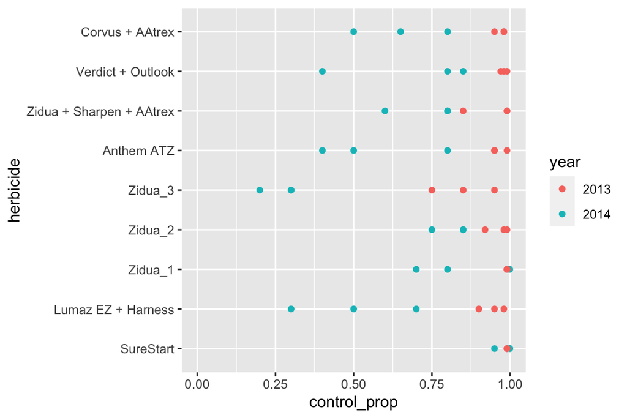

```r
ggplot(residual3, aes(x = herbicide, y = control_prop, color = year)) +
  geom_point() +
  coord_flip() +
  ylim(0, 1)
```

## Gráfico box-plot

Na figura abaixo adicionei um box-plot para melhorar a visualização da dispersão dos dados.

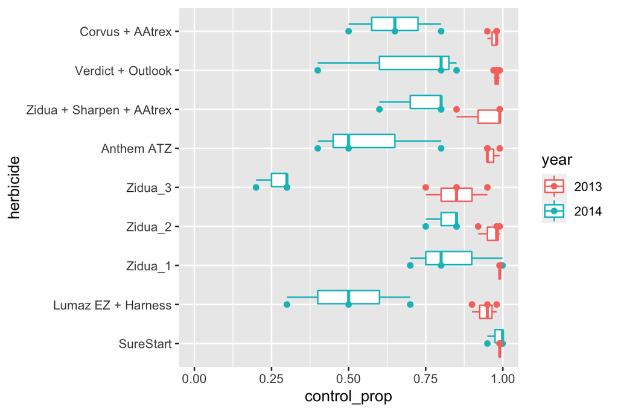

```r
ggplot(residual3, aes(x = herbicide, y = control_prop, color = year)) +
  geom_boxplot() + # veja que adicionei esse código para gerar o box plot
  geom_point() +
  coord_flip() +
  ylim(0, 1)
```

Aqui mostrei uma pequena parte do que pode ser feito com a parte de visuazlição exploratória de dados. Existe n possibilidades. Com o `ggplot` é possivel fazer figuras fantásticas! Duvida? Veja isso aqui: [TidyTuesday Bookmarks](https://www.notion.so/Data-Viz-Bookmarks-dc01718020bd4fd6a8a4ca80e6bce933).

# ANOVA

## Premissas da ANOVA

- Normalidade (Distribuição Gausseana)
- Homogeneidade de variância
- Independência

## Normalidade

Percentagem são dados tecnicamente não normalizados e vamos usar beta distribution.

## Homogeneidade de variâncias

Aqui vamos usar a função `leveneTest` para verificar a homogeneidade de variâncias entre os anos.

```r
library(car)
leveneTest(control_prop ~ year, data = residual3)
```

```
Levene's Test for Homogeneity of Variance (center = median)
      Df F value    Pr(>F)
group  1  25.857 5.112e-06 ***
      52
---
Signif. codes:  0 '***' 0.001 '**' 0.01 '*' 0.05 '.' 0.1 ' ' 1
```

Note que o P-valor é significativo, tecnicamente não poderia juntar os anos. Mas nessa análise vou juntar para facilitar.

- Definir juntar ou não dados de anos/locais distintos usando estatística é sempre uma discussão e não vamos entrar nesse mérito aqui.

## Independência

Relacionado como foi conduzido o estudo e como coletou os dados.

## Modelo

```r
library(glmmTMB)
```

```r
modelo <- glmmTMB(control_prop ~ # variável resposta
                    herbicide + # variável fixa
                    (1|rep/year), # efeitos randomizados
                  family = beta_family(link = "logit"),
                  REML = FALSE,
                  data = residual3)
```

### Efeitos randomizados

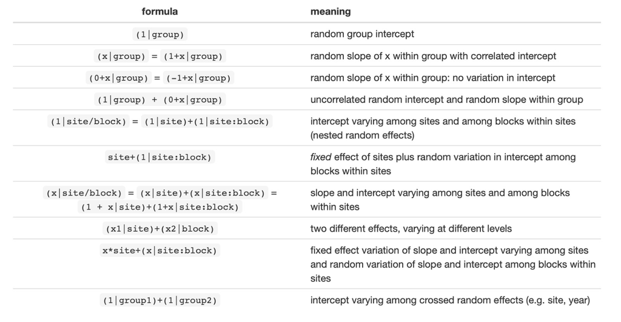

## Anova

```r
glmmTMB:::Anova.glmmTMB(modelo)
```

```
Analysis of Deviance Table (Type II Wald chisquare tests)

Response: control_prop
           Chisq Df Pr(>Chisq)
herbicide 61.851  8  2.018e-10 ***
---
Signif. codes:  0 '***' 0.001 '**' 0.01 '*' 0.05 '.' 0.1 ' ' 1
```

Pronto! Executamos o modelo e a ANOVA. O resultado diz que herbicide é significativo `Pr(>Chisq) = 2.018e-10 ***`.

Temos que avaliar o desempenho dos herbicidas no controle da planta daninha!

# Avaliando o controle da planta daninha com herbicidas

Vamos usar o pacote `emmeans`

```r
library(emmeans)
```

Primeira visualização usando a funccção `emmip`. Note que no código tem um atributo `type="response"`, que faz a transformação dos dados de volta para a proporção (controle).

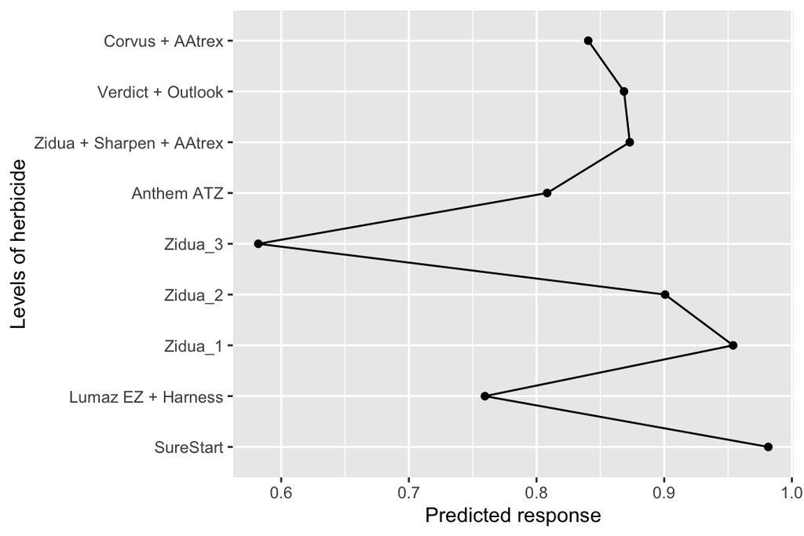

```r
emmip(modelo, ~ herbicide, type="response") + coord_flip()
```

## Médias marginais estimadas (médias dos quadrados mínimos)

A lsmeans forneceram os valores com o controle de plantas daninhas (prop), SE (erro padrão) e intervalos de confiança (lower.CL e upper.CL). Além disso, lsmeans fornece os contrastes aos pares entre tratamentos (herbicidas).

```r
lsmeans <- emmeans(modelo, # modelo
                   ~ herbicide, # efeito fixo
                   cont="pairwise", # tipo de comparação
                   type="response", # transforma os dados de volta ao original
                   alpha=0.05) # nivel

lsmeans
```

```
$emmeans
 herbicide                response     SE df lower.CL upper.CL
 SureStart                   0.982 0.0114 42    0.937    0.995
 Lumaz EZ + Harness          0.760 0.0876 42    0.545    0.893
 Zidua_1                     0.954 0.0254 42    0.866    0.985
 Zidua_2                     0.901 0.0471 42    0.758    0.963
 Zidua_3                     0.582 0.1137 42    0.352    0.782
 Anthem ATZ                  0.808 0.0752 42    0.613    0.918
 Zidua + Sharpen + AAtrex    0.873 0.0564 42    0.711    0.950
 Verdict + Outlook           0.869 0.0577 42    0.704    0.948
 Corvus + AAtrex             0.840 0.0665 42    0.659    0.935

Confidence level used: 0.95
Intervals are back-transformed from the logit scale

$contrasts
 contrast                                          odds.ratio      SE
 SureStart / (Lumaz EZ + Harness)                      16.801  8.8571
 SureStart / Zidua_1                                    2.561  1.4099
 SureStart / Zidua_2                                    5.854  3.0977
 SureStart / Zidua_3                                   38.111 20.2834
 SureStart / Anthem ATZ                                12.587  6.5982
 SureStart / (Zidua + Sharpen + AAtrex)                 7.721  4.0773
 SureStart / (Verdict + Outlook)                        8.036  4.2842
 SureStart / (Corvus + AAtrex)                         10.075  5.3264
 (Lumaz EZ + Harness) / Zidua_1                         0.152  0.0725
 (Lumaz EZ + Harness) / Zidua_2                         0.348  0.1443
 (Lumaz EZ + Harness) / Zidua_3                         2.268  0.7917
 (Lumaz EZ + Harness) / Anthem ATZ                      0.749  0.2760
 (Lumaz EZ + Harness) / (Zidua + Sharpen + AAtrex)      0.460  0.1817
 (Lumaz EZ + Harness) / (Verdict + Outlook)             0.478  0.1869
 (Lumaz EZ + Harness) / (Corvus + AAtrex)               0.600  0.2279
 Zidua_1 / Zidua_2                                      2.286  1.1233
 Zidua_1 / Zidua_3                                     14.879  7.0578
 Zidua_1 / Anthem ATZ                                   4.914  2.3184
 Zidua_1 / (Zidua + Sharpen + AAtrex)                   3.014  1.4545
 Zidua_1 / (Verdict + Outlook)                          3.137  1.5466
 Zidua_1 / (Corvus + AAtrex)                            3.933  1.9003
 Zidua_2 / Zidua_3                                      6.510  2.6663
 Zidua_2 / Anthem ATZ                                   2.150  0.8965
```

[output cut: 38 more lines]

```
 42    1  0.731  0.9980
 42    1  1.277  0.9326
 42    1 -3.100  0.0750
 42    1 -4.109  0.0051
 42    1 -4.064  0.0058
 42    1 -3.588  0.0220
 42    1 -1.232  0.9444
 42    1 -1.133  0.9654
 42    1 -0.578  0.9996
 42    1  0.096  1.0000
 42    1  0.653  0.9991
 42    1  0.559  0.9997

P value adjustment: tukey method for comparing a family of 9 estimates
Tests are performed on the log odds ratio scale
```

## Visualizar as médias de controle

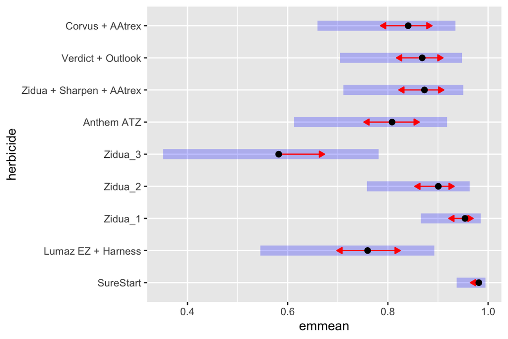

```r
plot(lsmeans, # lsmeans
     ~ herbicide, # efeito fixo
     comparisons = TRUE, # quero comparar
     type="response", # transforma os dados de volta ao original
     alpha=0.05, # nivel
     adjust="none") # ajuste, pode ser Tukey por exemplo - None = Fisher LSD
```

O ponto preto é a média do controle do herbicida e o roxo é o intervalo de confiança. A seta vermelha é uma comparação entre tratamentos; se uma seta vermelha não se sobrepõe, os tratamentos são diferentes.

#@ Separação por médias

Vamos usar o pacote `multcomp`

```r
library(multcomp)
```

```r
cld <- cld(lsmeans$emmeans, # o uso do $emmeans filtra o resultado de lsmeans para as medias
           alpha=0.05, # nivel
           Letters=letters, # usar letras
           adjust="none", # sem ajuste de medias
           reversed = TRUE) # a ---> z
cld
```

```
 herbicide                response     SE df lower.CL upper.CL .group
 SureStart                   0.982 0.0114 42    0.937    0.995  a
 Zidua_1                     0.954 0.0254 42    0.866    0.985  ab
 Zidua_2                     0.901 0.0471 42    0.758    0.963   bc
 Zidua + Sharpen + AAtrex    0.873 0.0564 42    0.711    0.950    cd
 Verdict + Outlook           0.869 0.0577 42    0.704    0.948    cd
 Corvus + AAtrex             0.840 0.0665 42    0.659    0.935    cd
 Anthem ATZ                  0.808 0.0752 42    0.613    0.918    cd
 Lumaz EZ + Harness          0.760 0.0876 42    0.545    0.893     d
 Zidua_3                     0.582 0.1137 42    0.352    0.782      e

Confidence level used: 0.95
Intervals are back-transformed from the logit scale
Tests are performed on the log odds ratio scale
significance level used: alpha = 0.05
```

Pronto! Sua análise está feita. Existe n possibilidades de reportar esses dados. Você pode criar uma tabela ou usar figuras, segue algumas sugestões abaixo.

# Reportando os dados

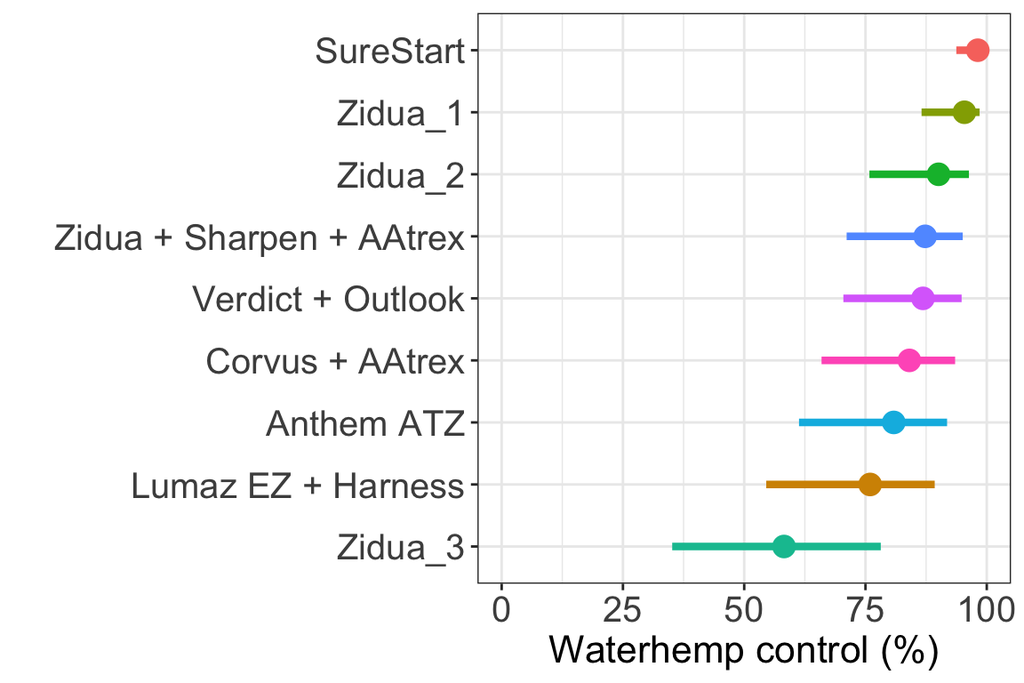

```r
ggplot(cld, aes(x=reorder(herbicide, response), y= response * 100, color = herbicide)) +
  geom_point(size=4) +
  geom_linerange(aes(ymin = lower.CL*100, ymax = upper.CL*100), size=1.5) +
  ylim(0,100) +
  labs(y="Waterhemp control (%)", x="") +
  theme_bw() +
  theme(axis.title = element_text(size=16),
        axis.text = element_text(size=15),
        legend.position = "none") +
 coord_flip()
```

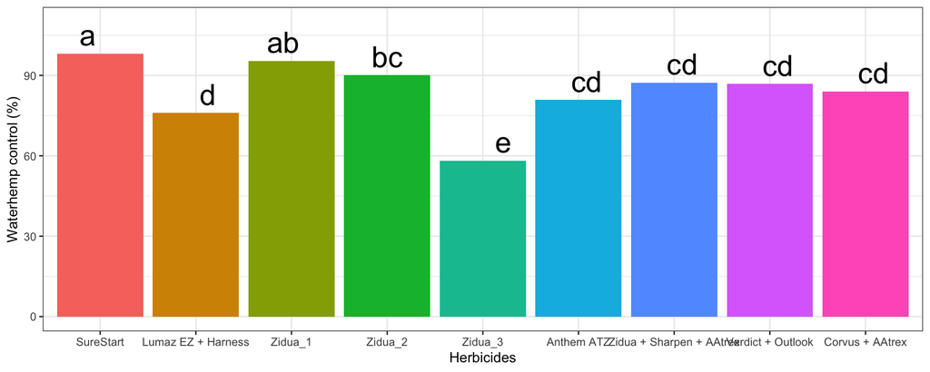

```r
ggplot(cld, aes(x=herbicide, y=response * 100, fill=herbicide, label=.group)) +
  geom_bar(stat="identity") +
  ylim(0,110) +
  labs(y="Waterhemp control (%)", x="Herbicides") +
  geom_text(nudge_y = 7, nudge_x = 0, size = 8) +
  theme_bw() +
  theme(legend.position = "none")
```

## Tabela

Vamos usar o pacote `kableExtra`

```r
library(kableExtra)
```

```r
kable(cld) %>%
  kable_styling()
```

|  | herbicide | response | SE | df | lower.CL | upper.CL | .group |
| --- | --- | --- | --- | --- | --- | --- | --- |
| 5 | SureStart | 0.9815083 | 0.0113984 | 42 | 0.9372839 | 0.9947233 | a |
| 2 | Zidua_1 | 0.9539639 | 0.0254327 | 42 | 0.8655886 | 0.9852244 | ab |
| 6 | Zidua_2 | 0.9006609 | 0.0471060 | 42 | 0.7580611 | 0.9632828 | bc |
| 9 | Zidua + Sharpen + AAtrex | 0.8730112 | 0.0564129 | 42 | 0.7111426 | 0.9504879 | cd |
| 8 | Verdict + Outlook | 0.8685050 | 0.0576837 | 42 | 0.7044304 | 0.9481974 | cd |
| 7 | Corvus + AAtrex | 0.8404720 | 0.0665060 | 42 | 0.6594246 | 0.9347929 | cd |
| 4 | Anthem ATZ | 0.8083161 | 0.0751900 | 42 | 0.6129593 | 0.9182229 | cd |
| 3 | Lumaz EZ + Harness | 0.7595689 | 0.0876114 | 42 | 0.5454170 | 0.8926849 | d |
| 1 | Zidua_3 | 0.5820680 | 0.1137236 | 42 | 0.3515661 | 0.7815461 | e |

# Leitura complementar

- Kniss et al. [Stats4ag](https://rstats4ag.org/)
- Bates et al. [Fitting Linear Mixed-Effects Models Using lme4](https://cran.r-project.org/web/packages/lme4/vignettes/lmer.pdf)
- [Getting started with emmeans](https://aosmith.rbind.io/2019/03/25/getting-started-with-emmeans/)